# Assignment_4_Sunspot Data

# Moving Averages

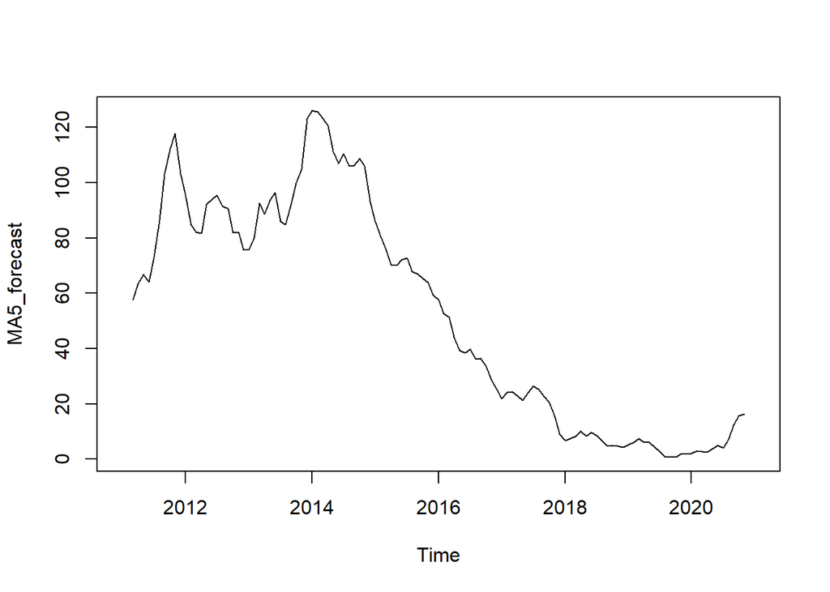

```r
MA5_forecast <- ma(T_Series,order=5)
MA9_forecast <- ma(T_Series,order=9)
plot(MA5_forecast)
```

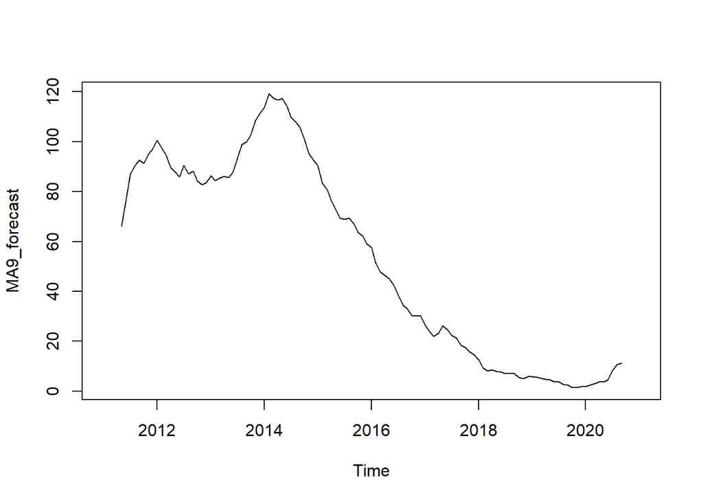

```r
plot(MA9_forecast)
```

# Other Attributes

# Exponential Smoothing

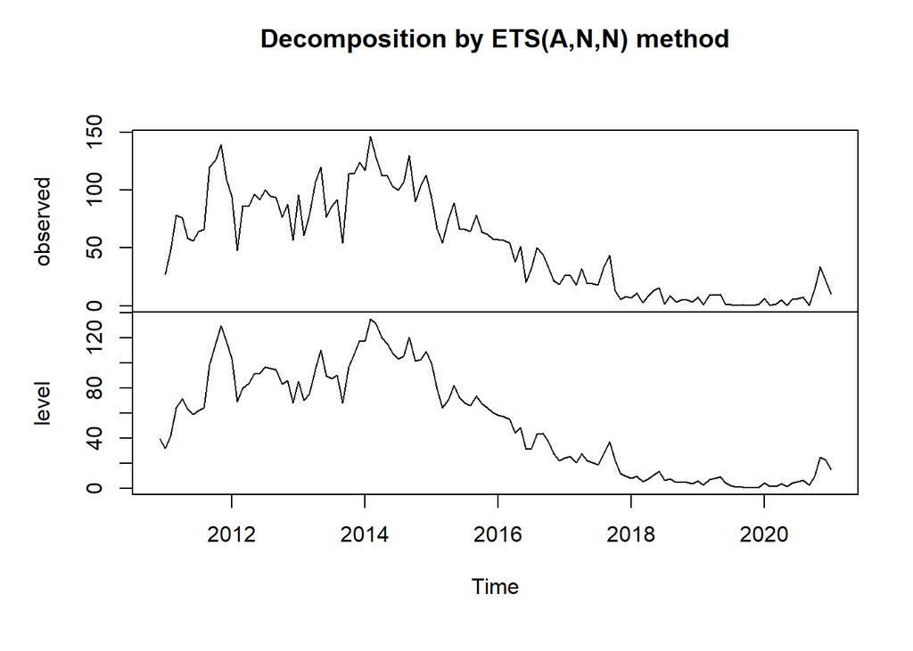

```r
ets_forecast <- ets(T_Series)
plot(ets_forecast)
```

```r
attributes(ets_forecast)
```

```
## $names
##  [1] "loglik"     "aic"        "bic"        "aicc"       "mse"
##  [6] "amse"       "fit"        "residuals"  "fitted"     "states"
## [11] "par"        "m"          "method"     "series"     "components"
## [16] "call"       "initstate"  "sigma2"     "x"
##
## $class
## [1] "ets"
```

```r
ets_forecast$mse
```

```
## [1] 263.3613
```

- Trend Component: The trend component represents the long-term movement or direction in the time series data.
- Seasonal Component: The seasonal component accounts for recurring patterns that occur at fixed intervals within the time series. These patterns are often related to calendar or seasonal factors and can include monthly, quarterly, or annual variations. #Error Component: It represents the residual variation in the time series data that cannot be explained by the trend or seasonality.

# Holt Winters

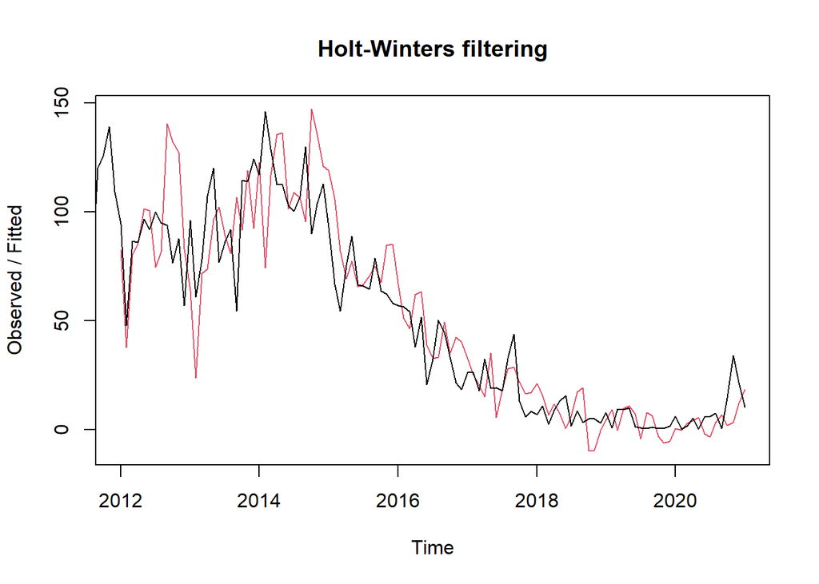

```r
HW<- HoltWinters(T_Series)
plot(HW)
```

```r
HW_forecast<-forecast(HW, h=6)
summary(HW_forecast)
```

```
##
## Forecast method: HoltWinters
##
## Model Information:
## Holt-Winters exponential smoothing with trend and additive seasonal component.
##
## Call:
## HoltWinters(x = T_Series)
##
## Smoothing parameters:
##  alpha: 0.2986607
##  beta : 0.01832422
##  gamma: 0.7647731
##
## Coefficients:
##            [,1]
## a    25.0684097
## b    -0.2701714
## s1  -13.7789708
## s2  -11.2670047
## s3   -7.7541592
## s4   -9.5001757
## s5   -7.8736513
## s6  -10.0545966
## s7   -8.4923263
## s8  -11.4426111
## s9   -3.9377939
## s10   3.9811237
## s11  -7.5086314
## s12 -13.3603591
##
## Error measures:
##                     ME     RMSE      MAE       MPE    MAPE      MASE      ACF1
## Training set -1.727378 19.52898 13.87069 -41.40084 147.466 0.6120081 0.2297166
##
## Forecasts:
##          Point Forecast     Lo 80    Hi 80     Lo 95    Hi 95
## Feb 2021       11.01927 -14.02518 36.06372 -27.28291 49.32145
## Mar 2021       13.26106 -12.91604 39.43817 -26.77337 53.29549
## Apr 2021       16.50374 -10.79762 43.80509 -25.25009 58.25756
## May 2021       14.48755 -13.93131 42.90641 -28.97535 57.95044
## Jun 2021       15.84390 -13.68712 45.37492 -29.31989 61.00770
## Jul 2021       13.39279 -17.24624 44.03181 -33.46556 60.25113
```

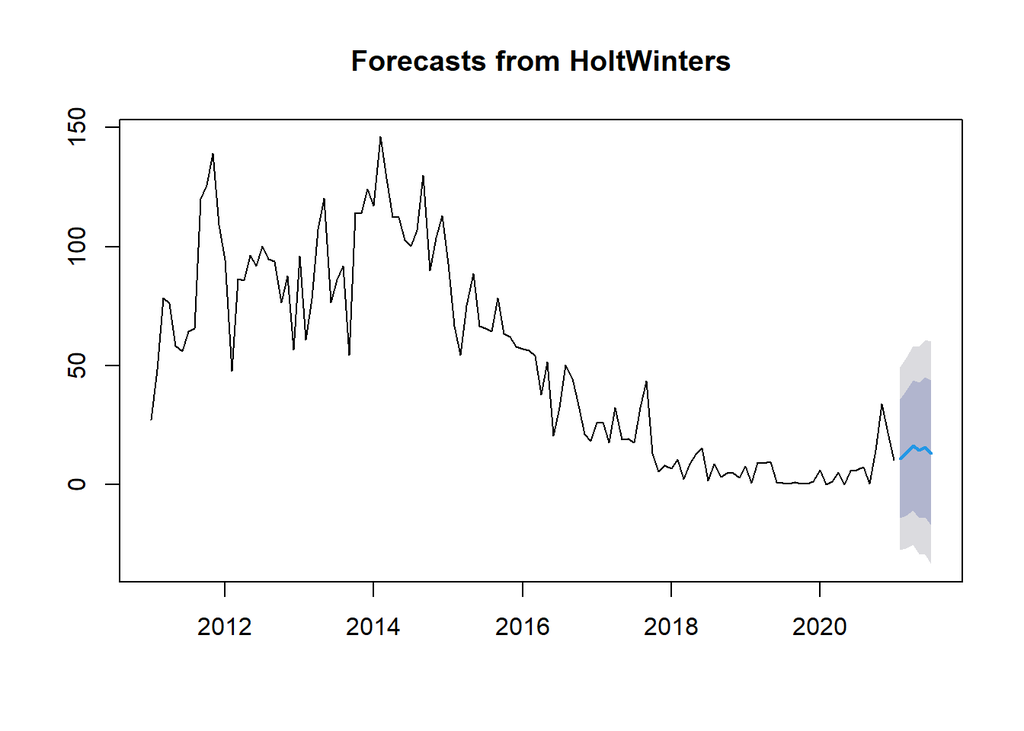

```r
plot(HW_forecast)
```

```r
SSE_Simple <- HoltWinters(T_Series,beta=FALSE,gamma=FALSE)
attributes(SSE_Simple)
```

```
## $names
## [1] "fitted"       "x"            "alpha"        "beta"         "gamma"
## [6] "coefficients" "seasonal"     "SSE"          "call"
##
## $class
## [1] "HoltWinters"
```

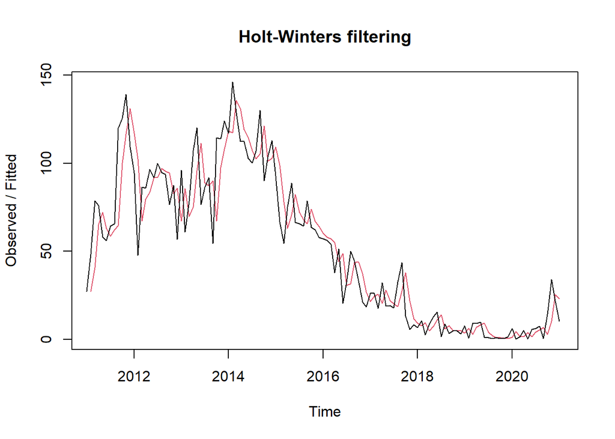

```r
plot(SSE_Simple)
```

```r
SSE_Simple$SSE
```

```
## [1] 32021.52
```

```r
head(SSE_Simple$fitted)
```

```
##              xhat    level
## Feb 2011 27.30000 27.30000
## Mar 2011 40.78707 40.78707
## Apr 2011 65.07210 65.07210
## May 2011 72.15467 72.15467
## Jun 2011 63.19240 63.19240
## Jul 2011 58.63737 58.63737
```

Level Component(α): The level component represents the estimated baseline or average value of the time series. It accounts for the overall level of the data.

Trend Component (β): The trend component accounts for the rate of change or trend in the data. It captures whether the data is increasing or decreasing over time.

# Combining all charts in one

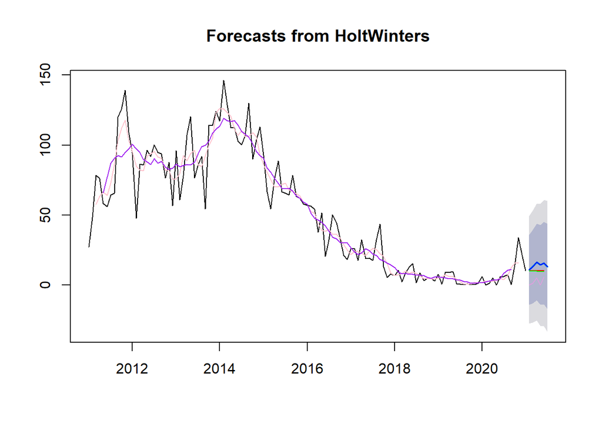

```r
plot(HW_forecast)
lines(naive_forecast$mean,col="red")
lines(rwf_forecast$mean,col="green")
lines(snaive_forecast$mean,col="plum")
lines(HW_forecast$mean,col="blue")
lines(ets_forecast$mean,col="orange")
lines(MA5_forecast,col="pink")
lines(MA9_forecast,col="purple")
```

# Accuracy Measures

```r
accuracy(mean_forecast)
```

```
##                         ME     RMSE      MAE       MPE     MAPE     MASE
## Training set -2.524152e-15 42.01061 36.91293 -1172.769 1209.548 1.628687
##                   ACF1
## Training set 0.9124916
```

```r
accuracy(naive_forecast)
```

```
##                      ME     RMSE      MAE       MPE     MAPE      MASE
## Training set -0.1408333 17.08782 11.86417 -81.25677 112.8087 0.5234756
##                    ACF1
## Training set -0.2620824
```

```r
accuracy(rwf_forecast)
```

```
##                         ME     RMSE      MAE       MPE     MAPE      MASE
## Training set -1.043971e-15 17.08724 11.86182 -77.78288 110.9956 0.5233721
##                    ACF1
## Training set -0.2620824
```

```r
accuracy(snaive_forecast)
```

```
##                     ME    RMSE      MAE      MPE     MAPE MASE     ACF1
## Training set -7.902752 29.9261 22.66422 -174.293 198.4407    1 0.600019
```

```r
accuracy(ets_forecast)
```

```
##                      ME     RMSE      MAE       MPE     MAPE      MASE
## Training set -0.3258254 16.22841 11.56717 -72.58582 97.94194 0.5103713
##                    ACF1
## Training set 0.05774778
```

```r
accuracy(HW_forecast)
```

```
##                     ME     RMSE      MAE       MPE    MAPE      MASE      ACF1
## Training set -1.727378 19.52898 13.87069 -41.40084 147.466 0.6120081 0.2297166
```

# Accuracy Measures Calculated:

Mean Error (ME) Root Mean Squared Error (RMSE) Mean Absolute Error (MAE) Mean Percentage Error (MPE) Mean Absolute Percentage Error (MAPE) Mean Absolute Scaled Error (MASE) Autocorrelation of errors at lag 1 (ACF1) Accuracy Measure Selected for Model Comparison: Root Mean Squared Error (RMSE): RMSE is the square root of the MSE and is often used to express error in the same units as the data. Generally, a lower RMSE indicates a higher level of accuracy in forecasting. The RMSE value for the different forecasts is as follows: - Mean Forecast Method: 42.01061 - Naive Forecast Method: 17.08782 - Random Walk Forecast Method: 17.08724 - Seasonal Naive Forecast Method: 29.9261 - ETS Forecast Method: 16.22841 - Holt Winters Filtering Method: 19.52898